## Goal:

I want to see if my fitted topics have anchor words (those genes that have proportions for some topics, and very small proportions in other topics) for all its topics.

## Result:

# Comment:

- The fitted topic does not quite follow the anchor word assumption.
  - Why? For a few topics, the most dominant genes are also dominant in other topics

SEE `In [6]`

- In one topic, top 10 genes take huge proportions (over 80%)
- In most topic, top 10 genes take more than 10% proportions

```python
## get all the Anchor words of a factor

dataname = "gtex"
method = "ccd"

import sys
sys.path.insert(0, "../code")
import os
import time
import numpy as np
from numpy import loadtxt
from numpy import savetxt
from time  import time
from misc import poisson2multinom


# SCRIPT SETTINGS
# ---------------
# These variables specify the names of the input files.
datadir          = os.path.join("../../topics_bigdata/","output")
factorsfile  = "{}_factors_{}.csv.gz".format(dataname, method)
loadingsfile  = "{}_loadings_{}.csv.gz".format(dataname, method)


# These variables specify the names of the output files.
#outdir          = os.path.join("./../topics-simulation-bigdata/","output")


# LOAD INITIAL ESTIMATES
# ----------------------
# I add a small constant to the initial estimates of the factors and
# loadings because the multiplicative updates do not deal well with
# estimates that are exactly zero.
print("Loading factors and loadings.")
factorsfile  = os.path.join(datadir,factorsfile)
loadingsfile = os.path.join(datadir,loadingsfile)
F = loadtxt(factorsfile,delimiter = ",")
L = loadtxt(loadingsfile,delimiter = ",")
K  = F.shape[1]

print("Loaded {:d} x {:d} factors matrix, ".format(F.shape[0],F.shape[1]) +
      "and {:d} x {:d} loadings matrix".format(L.shape[0],L.shape[1]))
# SESSION INFO
# ------------
print(sys.version)
print("numpy " + np.__version__)
```

```
Loading factors and loadings.
Loaded 55863 x 20 factors matrix, and 11688 x 20 loadings matrix
3.6.8 |Anaconda, Inc.| (default, Dec 29 2018, 19:04:46)
[GCC 4.2.1 Compatible Clang 4.0.1 (tags/RELEASE_401/final)]
numpy 1.14.2
```

```python
## read gene labels
genefile = "genes_label.csv"
genefile = os.path.join(datadir,genefile)
with open(genefile) as f:
    genes = f.read().splitlines()
genes= np.array(genes)
```

```python
# Convert the Poisson model parameters to the parameters for the
# multinomial model.
A, _ = poisson2multinom(F,L.T)
print("average proportion {}".format((np.mean(A))))
print("median proportion  {}".format((np.median(A))))
print("max proportion     {}".format((np.max(A))))
```

```
average proportion 1.7900936218964287e-05
median proportion  9.298862034779333e-09
max proportion     0.16650488434022273
```

```python
ancw_counter = {}
for i in range(K):
    ancw_counter[i] = 0
up = 1e-3
dow = 1e-10
for x in A:
    idx = np.argsort(x)
    if x[idx[-1]] > up and x[idx[-2]] < dow:
        ancw_counter[idx[-1]] += 1
```

```python
print("topic idx vs number of anchor word")
for k,v in ancw_counter.items():
    print("topic {}: {} anchor words\n".format(k+1, v))
```

```
topic idx vs number of anchor word
topic 1: 4 anchor words

topic 2: 0 anchor words

topic 3: 5 anchor words

topic 4: 3 anchor words

topic 5: 0 anchor words

topic 6: 4 anchor words

topic 7: 1 anchor words

topic 8: 2 anchor words

topic 9: 4 anchor words

topic 10: 0 anchor words

topic 11: 0 anchor words

topic 12: 0 anchor words

topic 13: 3 anchor words

topic 14: 0 anchor words

topic 15: 3 anchor words

topic 16: 0 anchor words

topic 17: 1 anchor words

topic 18: 13 anchor words

topic 19: 3 anchor words

topic 20: 0 anchor words
```

# Comment:

The fitted topic does not quite follow the anchor word assumption.

Why? For a few topics, the most dominant genes are also dominant in other topics

See below

## Comparing with information from GTEx portal

Our model is able to find some top genes that are expressed only in one or a few tissue. Yet some top genes have similar expression pattern.

More detailed cmparison below:

(from https://gtexportal.org/home/ and https://github.com/stephenslab/topics/blob/zihao/docs/gtex_loadings_plot_ccd.pdf)

- TOPIC 12: (proportion of top 10 genes: 0.834395386446502)
  - dominant genes are "mitochondrially encoded"
  - The expression of the most prominant gene are quite similar to the topic loading on that gene
- TOPIC 18:
  - top genes are almost only expressed in pancreas from GTEx portal, which is exactly what our loading shows for this topic
- TOPIC 3,5,17,4,8
  - the expression of top gene has very similar pattern, and also only seen in one tissue
- TOPIC 13:
  - the expression of the top gene is not very similar to the corresponding loadings, especially the expression in brain is much smaller in loading
- TOPIC 15
  - the expression of top gene is similar to loading in tissues except in cervix (high gene expression which is not observed in corresponding loading)
- TOPIC 9:
  - high expression of top 2 genes only found in stomach
  - high expression of 5th,9th genes only found in salivary gland
  - expression pattern of 3th, 4th,5th,8th,10th similar (highly expressed in a few and probably similar tissues)
  - expression of 6th and 7th are simialr
- TOPIC 20
  - top 3 genes are highly expressed in Cells - Transformed fibroblasts (a label not shown in my loading plot)
  - similar to topic 9, many genes are highly expressed in many tissues
- TOPIC 19
  - top 3 genes highly expressed in pituitary
  - 4th 5th highly expressed in adrenal gland
  - many other genes highly expressed in many other tissues (also similar pattern to many other)
- TOPIC 6
  - Top 2 genes are highly expressed in skin
  - many other genes highly expressed in many other tissues
- The rest of the topics:
  - Some have sparse loading, but among the top genes, some express similar to the loading, while some others are highly expressed in many tussues

```python
n_top = 10
topics = {}

for i,x in enumerate(A.T):
    idx = np.argsort(x,)
    top_idx = idx[-n_top:]
    top_idx = top_idx[::-1]
    prop_top = x[top_idx].sum()
    top_genes = genes[top_idx]
    topics[i+1] = {"prop_top": prop_top, "top_genes":top_genes, "proportions":x[top_idx]}

prop_tops_ix = np.argsort([v["prop_top"]  for k,v in topics.items()])
prop_tops_ix = prop_tops_ix[::-1]
for i in prop_tops_ix:
    print("###-----------------------------###\n")
    print("TOPIC {} TOP GENES:\n".format(i+1))
    print("proportion of top {} genes: {}".format(n_top, topics[i+1]["prop_top"]))
    print("gene names\n")
    print(topics[i+1]["top_genes"])
    print("gene proportions")
    print(topics[i+1]["proportions"])
    print("\n")
```

```
###-----------------------------###

TOPIC 12 TOP GENES:

proportion of top 10 genes: 0.834395386446502
gene names

['ENSG00000198804.2' 'ENSG00000198886.2' 'ENSG00000210082.2'
 'ENSG00000198938.2' 'ENSG00000198727.2' 'ENSG00000198712.1'
 'ENSG00000198899.2' 'ENSG00000198763.3' 'ENSG00000198888.2'
 'ENSG00000198786.2']
gene proportions
[0.16650488 0.14095751 0.08975821 0.08142539 0.0732128  0.07110607
 0.06276802 0.05854933 0.05726856 0.03284461]


###-----------------------------###

TOPIC 18 TOP GENES:

proportion of top 10 genes: 0.3696325457020334
gene names

['ENSG00000204983.8' 'ENSG00000091704.5' 'ENSG00000175535.6'
 'ENSG00000169347.12' 'ENSG00000115386.5' 'ENSG00000153002.7'
 'ENSG00000170835.10' 'ENSG00000142789.15' 'ENSG00000137392.5'
 'ENSG00000168928.8']
gene proportions
[0.06411633 0.06044691 0.0436346  0.0417399  0.03808407 0.03417017
 0.02572667 0.02476008 0.02080838 0.01614544]


###-----------------------------###

TOPIC 3 TOP GENES:

proportion of top 10 genes: 0.2581661699075148
gene names

['ENSG00000244734.2' 'ENSG00000188536.8' 'ENSG00000163220.10'
```

[output cut: 263 more lines]

```

###-----------------------------###

TOPIC 2 TOP GENES:

proportion of top 10 genes: 0.037728850221571124
gene names

['ENSG00000210082.2' 'ENSG00000198712.1' 'ENSG00000198938.2'
 'ENSG00000198899.2' 'ENSG00000132639.8' 'ENSG00000198668.6'
 'ENSG00000198763.3' 'ENSG00000198888.2' 'ENSG00000198886.2'
 'ENSG00000087460.19']
gene proportions
[0.00762924 0.00394426 0.00375644 0.00368688 0.00358883 0.00344738
 0.00332013 0.00315983 0.00293002 0.00226586]
```

## hist of log proportion

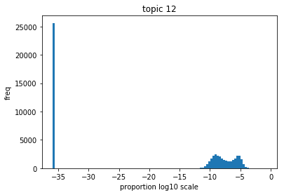

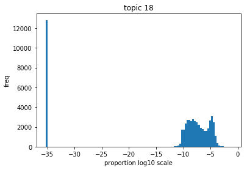

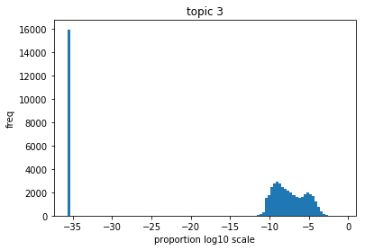

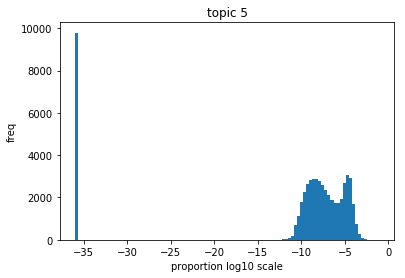

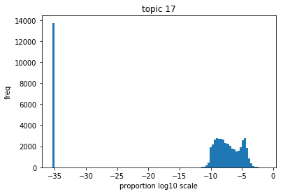

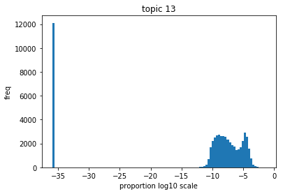

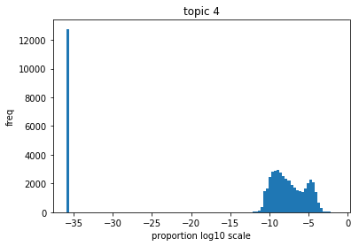

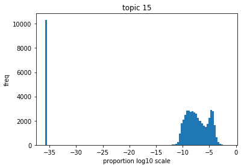

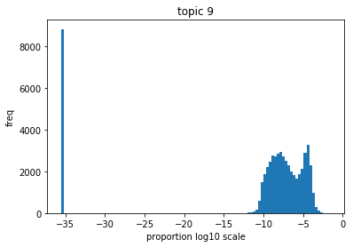

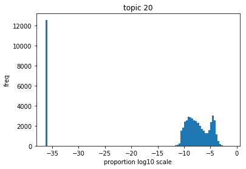

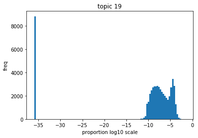

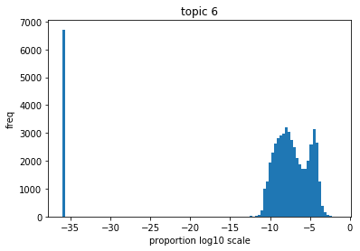

[8 more figures not shown]

```python
import matplotlib.pyplot as plt
for i in prop_tops_ix:
    x = A[:,i]
    plt.hist(np.log10(x), bins=100)
    plt.title("topic {}".format(i+1))
    plt.xlabel("proportion log10 scale")
    plt.ylabel("freq")
    plt.show()
```